# INFSCI 2160 DATA MINING HOMEWORK 5

Jing Pang

4/2/2019

```r
packageCheck <- function(x){
  for(i in x){
    if(!require(i, character.only = TRUE)){
      install.packages(i, dependencies = TRUE)
      require( i , character.only = TRUE )
    }
  }
}
packageCheck(c("tm", "lsa", "ggplot2", "dplyr", "stringr", "qdapDictionaries"))
# import data
df <- read.csv("~/Dropbox/19 Spring Term/INFSCI_2160_DM/HWs/HW5/HOMEWORK_5_REUTERS_NEWSGROUP.csv")
```

## Task 1 (Text Mining):

#### Analyze the topical clusters from text data. We will use the Reuters newsgroup dataset available on Piazza. The dataset description can be found here: https://www.cs.umb.edu/~smimarog/textmining/datasets/

- Plot the histogram of number of documents per topic. Find and list the four most popular topics in terms of number of documents.

```r
# analysis
head(df)
```

```
##         Topic
## 1 alt.atheism
## 2 alt.atheism
## 3 alt.atheism
## 4 alt.atheism
## 5 alt.atheism
## 6 alt.atheism
##                                                                                                                                                                                                                                                                                                          …
## 1 amus atheist and agnost articl timmbak mcl timmbak mcl ucsb edu clam bake timmon write fallaci atheism faith hear faq beckon onc wonder rule delet you correct you didn conspiraci correct hard atheism faith rule don mix appl orang can you that extermin mongol wors stalin khan conquer peopl unsym…
## 2                                                                                                                                                                                                                                                                                                        …
## 3                                                                                                                                                                                                                                                                                                        …
## 4                                                                                                                                                                                                year can that christian moral articl rusnew manti mathew manti mathew write mccullou snake wisc edu mark…
## 5                                                                                                                                                                                                                                                                                                        …
## 6                                                                                                                                                                                                                                                                                                        …
```

```r
dim(df)
```

```
## [1] 7511    2
```

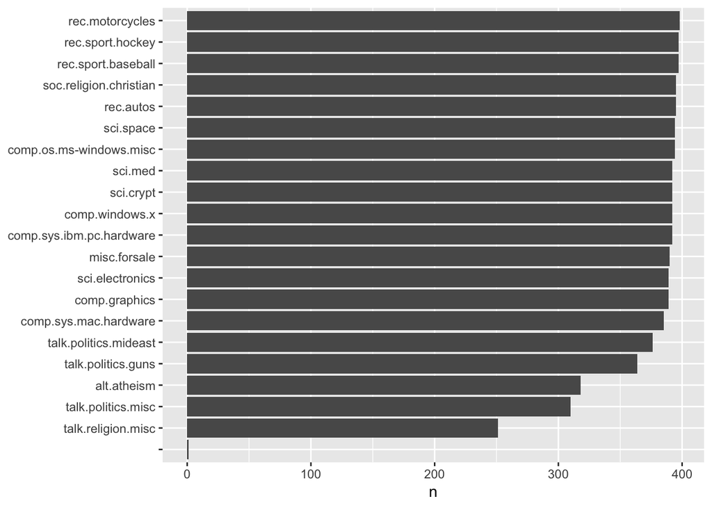

```r
# count frequency of topics
TopicFreq <- df %>%
  dplyr::count(df$Topic, sort=TRUE)
TopicFreq <- as.data.frame(TopicFreq)
colnames(TopicFreq)[1] <- "Topic"
colnames(TopicFreq)[2] <- "Freq"

# plot histogram of number of documents per topic
df %>%
  dplyr::count(Topic, sort = TRUE) %>%
  mutate(Topic = reorder(Topic, n)) %>%
  ggplot(aes(Topic, n)) +
  geom_col() +
  xlab(NULL) +
  coord_flip()
```

```r
# Top 4 most popular tocpis in terms of documents
top4 <- TopicFreq[1:4,]
top4
```

```
##                Topic Freq
## 1    rec.motorcycles  398
## 2 rec.sport.baseball  397
## 3   rec.sport.hockey  397
## 4          rec.autos  395
```

- Extract contents in these top 4 topics as your corpus. Run pre-processing on this corpus and use terms that appear at least 4 times in the corpus to create a term-document matrix. Use the term-document matrix to generate an MDS plot (reviewed in class) where each node represents a document with color indicating its topic.

```r
# extract contents in these top 4 topics
df_new <- inner_join(df, top4, by = c("Topic" = "Topic"))

# combine into a new file corpus
corpus <- Corpus(VectorSource(df_new$Content))

# pre-processing corpus
corpus <- tm_map(corpus, tolower) ## convert text to lower case
corpus <- tm_map(corpus, removePunctuation) ## remove punctuations
corpus <- tm_map(corpus, removeNumbers) ## remove numbers
corpus <- tm_map(corpus, function(x) removeWords(x, stopwords("english"))) ## remove stopwords
corpus <- tm_map(corpus, stemDocument, language = "english") ## stemming
# transfer corpus to term-document
td <- TermDocumentMatrix(corpus)
inspect(td[1,])
```

```
## <<TermDocumentMatrix (terms: 1, documents: 1587)>>
## Non-/sparse entries: 2/1585
## Sparsity           : 100%
## Maximal term length: 6
## Weighting          : term frequency (tf)
## Sample             :
##         Docs
## Terms    1 10 2 3 4 5 6 7 8 9
##   adsorb 1  0 0 4 0 0 0 0 0 0
```

```r
# downsize corpus by removing terms that appear less than 4 times
is.word  <- function(x) x %in% GradyAugmented
termsBigger4 <- findFreqTerms(td, 4)
termToRemove <- setdiff(termsBigger4, GradyAugmented)
# cover old corpus with new corpus that removing terms appeared less than 4 times
corpus <- tm_map(corpus, content_transformer(removeWords), termToRemove)
```

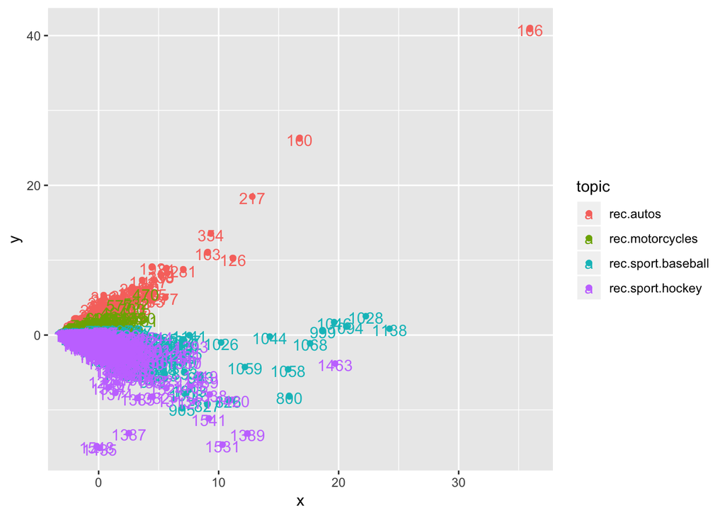

```r
# build final term-document from new corpus
td.mat <- as.matrix(TermDocumentMatrix(corpus))

# distance matrix
dist.mat <- dist(t(as.matrix(td.mat))) ## compute distance matrix
# dist.mat  ## check distance matrix

## generate mds plot
doc.mds <- cmdscale(dist.mat, k = 2)
data <- data.frame(x = doc.mds[, 1], y = doc.mds[, 2], topic = df_new$Topic, id = row.names(df_new))
ggplot(data, aes(x = x, y = y, color=topic)) +
  geom_point() + geom_text(aes(x = x, y = y - 0.2, label = id))
```

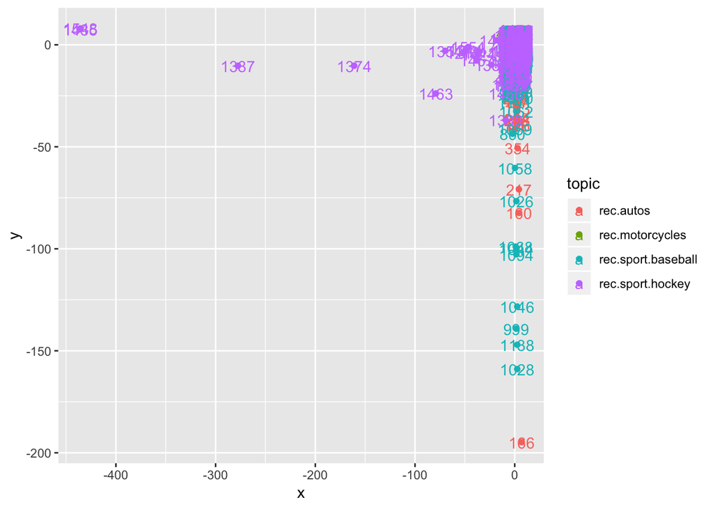

```r
td.mat.w = lw_tf(td.mat) * gw_idf(td.mat)  ## tf-idf weighting
dist.mat = dist(t(as.matrix(td.mat.w))) ## compute distance matrix

## generate mds plot using new distance matrix
doc.mds <- cmdscale(dist.mat, k = 2)
data <- data.frame(x = doc.mds[, 1], y = doc.mds[, 2], topic = df_new$Topic, id = row.names(df_new))
ggplot(data, aes(x = x, y = y, color=topic)) +
  geom_point() + geom_text(aes(x = x, y = y - 0.2, label = id))
```

- Write down your observation based on these two plots.

## Task 2 (Recommendation):

#### Create a recommender system based on the book rating data available here: http://www2.informatik.uni-freiburg.de/~cziegler/BX/. In the dataset, load the BX-Book-Ratings.csv and BX-Books.csv data. Extract books published from 1998 to present. Create a book rating matrix from these books, and in this matrix, only consider books that were rated by at least 10 users, and users that rated at least 10 books.

```r
packageCheck <- function(x){
  for(i in x){
    if(!require(i, character.only = TRUE)){
      install.packages(i, dependencies = TRUE)
      require( i , character.only = TRUE )
    }
  }
}
packageCheck(c("recommenderlab", "reshape2", "ggplot2", "dplyr", "plyr"))
# load data
bookrating <- read.csv("~/Dropbox/19 Spring Term/INFSCI_2160_DM/HWs/HW5/BX-Book-Ratings.csv", sep=";")
books <- read.csv("~/Dropbox/19 Spring Term/INFSCI_2160_DM/HWs/HW5/BX-Books.csv", sep=";")

# summary
head(bookrating)
```

```
##   User.ID       ISBN Book.Rating
## 1  276725 034545104X           0
## 2  276726 0155061224           5
## 3  276727 0446520802           0
## 4  276729 052165615X           3
## 5  276729 0521795028           6
## 6  276733 2080674722           0
```

```r
head(books)
```

```
##         ISBN
## 1 0195153448
## 2 0002005018
## 3 0060973129
## 4 0374157065
## 5 0393045218
## 6 0399135782
##                                                                                           Book.Title
## 1                                                                                Classical Mythology
## 2                                                                                       Clara Callan
## 3                                                                               Decision in Normandy
## 4 Flu: The Story of the Great Influenza Pandemic of 1918 and the Search for the Virus That Caused It
## 5                                                                             The Mummies of Urumchi
## 6                                                                             The Kitchen God's Wife
##            Book.Author Year.Of.Publication                  Publisher
```

[output cut: 27 more lines]

```r
summary(bookrating)
```

```
##     User.ID               ISBN         Book.Rating
##  Min.   :     2   0971880107:  1080   Min.   : 0.000
##  1st Qu.:187517   0316666343:   551   1st Qu.: 0.000
##  Median :217173   0385504209:   361   Median : 0.000
##  Mean   :212860   0060928336:   308   Mean   : 2.694
##  3rd Qu.:244833   0312195516:   303   3rd Qu.: 7.000
##  Max.   :278854   044023722X:   280   Max.   :10.000
##                   (Other)   :490930
```

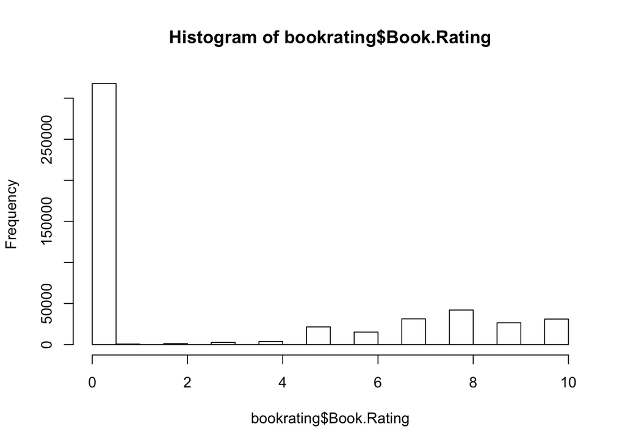

```r
# histogram of book rating
hist(bookrating$Book.Rating)
```

```r
# convert numeric to factor
bookrating$User.ID <- as.factor(bookrating$User.ID)

# create function to find books published from 1998 to present
func_published <- function(x) {
  x >= 1998
}
# get books published from 1998 to present
books$Year.Of.Publication <- as.numeric(as.character(books$Year.Of.Publication))
books$correct <- lapply(books$Year.Of.Publication, func_published)
d_book <- subset.data.frame(books, correct=="TRUE")

# create function to select at least 10
func_atleaseten <- function(x) {
  x >= 10
}
# count user and ISBN
d1 <- plyr::count(bookrating$User.ID)
d1$correct <- lapply(d1$freq, func_atleaseten)
d1 <- subset.data.frame(d1, correct=="TRUE")

d2 <- plyr::count(bookrating$ISBN)
d2$correct <- lapply(d2$freq, func_atleaseten)
d2 <- subset.data.frame(d2, correct=="TRUE")

# remove users and ISBN which is not meet requirement.
df <- inner_join(bookrating, d_book, by = c("ISBN" = "ISBN"))
df <- inner_join(df, d1, by = c("User.ID" = "x"))
df <- inner_join(df, d2, by = c("ISBN" = "x"))
# convert dataframe to matrix
r <- acast(df[,1:3], User.ID ~ ISBN)
```

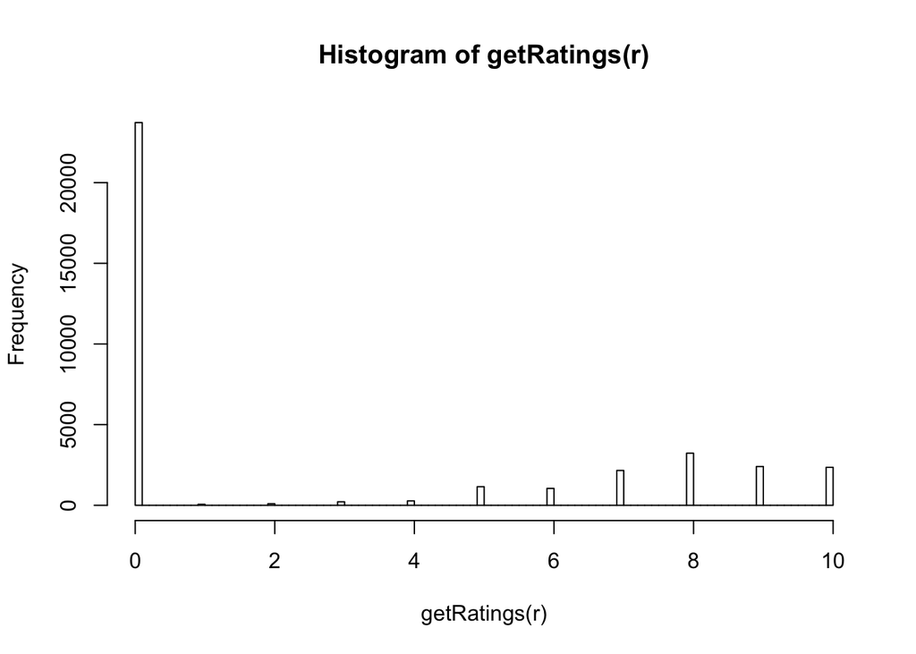

```r
# convert to recommendation matrix
r <- as(r,"realRatingMatrix")
# normalize
r_m <- recommenderlab::normalize(r)
r_z <- recommenderlab::normalize(r,method="Z-score")

# plot histogram to show the distribution of the ratings and normalized ratings
hist(getRatings(r),breaks = 100)
```

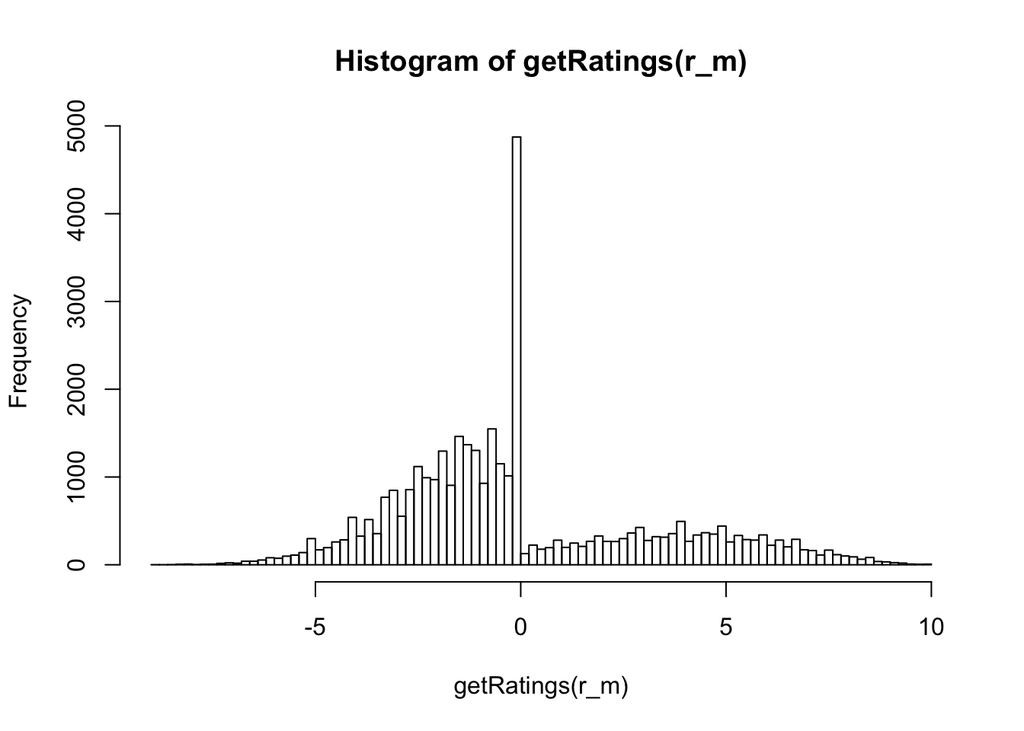

```r
hist(getRatings(r_m),breaks = 100)
```

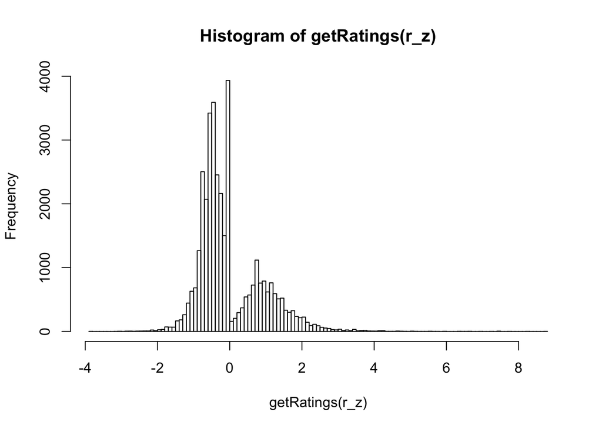

```r
hist(getRatings(r_z),breaks = 100)
```

- Run and test a recommender system built with different recommendation methods, including random, popular, user-based collaborative filtering, item-based collaborative filtering. Evaluate the different methods by using k-fold cross-validation (k = 4). Generate a performance table in terms of performance measures MAE, MSE, and RMSE. Hint: use “recommenderlab” library. Documentation can be found here: https://www.rdocumentation.org/packages/recommenderlab/versions/0.2-4

```r
set.seed(1234)
e <- evaluationScheme(r, method="cross-validation", train=0.9, k=4, given=-1, goodRating=5)
e
```

```
## Evaluation scheme using all-but-1 items
## Method: 'cross-validation' with 4 run(s).
## Good ratings: >=5.000000
## Data set: 4266 x 1424 rating matrix of class 'realRatingMatrix' with 36706 ratings.
```

```r
## create a random collaborative filtering
r1 <- Recommender(getData(e, "train"), "RANDOM")

## create an popular collaborative filtering
r2 <- Recommender(getData(e, "train"), "POPULAR")

## create a user-based collaborative filtering
r3 <- Recommender(getData(e, "train"), "UBCF")

## create an item-based collaborative filtering
r4 <- Recommender(getData(e, "train"), "IBCF")

## compute predicted ratings for the known part (rated items) of the test data
p1 <- predict(r1, getData(e, "known"), type="ratings")
p2 <- predict(r2, getData(e, "known"), type="ratings")
p3 <- predict(r3, getData(e, "known"), type="ratings")
p4 <- predict(r4, getData(e, "known"), type="ratings")

## calculate the error between the prediction and the unknown part of the test data
error <- rbind(
  RANDOM = calcPredictionAccuracy(p1, getData(e, "unknown")),
  POPULAR = calcPredictionAccuracy(p2, getData(e, "unknown")),
  UBCF = calcPredictionAccuracy(p3, getData(e, "unknown")),
  IBCF = calcPredictionAccuracy(p4, getData(e, "unknown"))
)
error
```

```
##             RMSE      MSE      MAE
## RANDOM  4.869931 23.71623 3.573227
## POPULAR 4.190181 17.55762 3.224765
## UBCF    4.111275 16.90258 3.080142
## IBCF    4.966228 24.66342 3.497186
```

```r
## comparison of several recommender algorithms
set.seed(1234)
scheme <- evaluationScheme(r, method="cross-validation", train=0.9, k=4, given=-1, goodRating=5)
scheme
```

```
## Evaluation scheme using all-but-1 items
## Method: 'cross-validation' with 4 run(s).
## Good ratings: >=5.000000
## Data set: 4266 x 1424 rating matrix of class 'realRatingMatrix' with 36706 ratings.
```

```r
algorithms <- list(
  "random items" = list(name="RANDOM", param=NULL),
  "popular items" = list(name="POPULAR", param=NULL),
  "user-based CF" = list(name="UBCF", param=list(nn=50)),
  "item-based CF" = list(name="IBCF", param=list(k=50))
)
## run algorithms
results_topN <- evaluate(scheme, algorithms, type = "topNList",
                    n=c(1, 3, 5, 10, 15, 20))
```

```
## RANDOM run fold/sample [model time/prediction time]
##   1  [0.019sec/2.51sec]
##   2  [0.001sec/2.235sec]
##   3  [0.001sec/2.412sec]
##   4  [0sec/2.511sec]
## POPULAR run fold/sample [model time/prediction time]
##   1  [0.029sec/6.578sec]
##   2  [0.007sec/6.658sec]
##   3  [0.006sec/6.813sec]
##   4  [0.005sec/6.598sec]
## UBCF run fold/sample [model time/prediction time]
##   1  [0.026sec/40.403sec]
##   2  [0.005sec/39.984sec]
##   3  [0.005sec/40.195sec]
##   4  [0.005sec/40.153sec]
## IBCF run fold/sample [model time/prediction time]
##   1  [41.708sec/0.78sec]
##   2  [41.967sec/0.609sec]
##   3  [41.677sec/0.668sec]
##   4  [41.626sec/0.636sec]
```

```r
results_topN
```

```
## List of evaluation results for 4 recommenders:
## Evaluation results for 4 folds/samples using method 'RANDOM'.
## Evaluation results for 4 folds/samples using method 'POPULAR'.
## Evaluation results for 4 folds/samples using method 'UBCF'.
## Evaluation results for 4 folds/samples using method 'IBCF'.
```

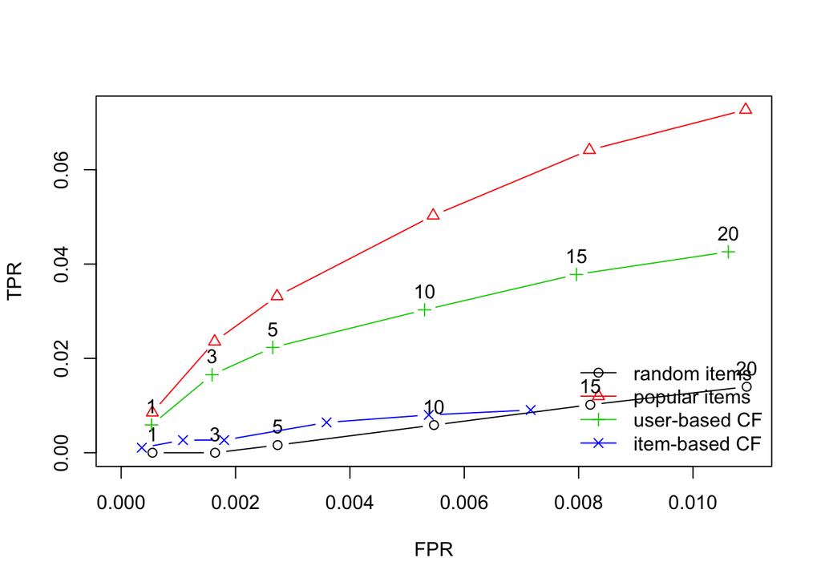

```r
plot(results_topN, annotate=c(1,3), legend="bottomright")
```

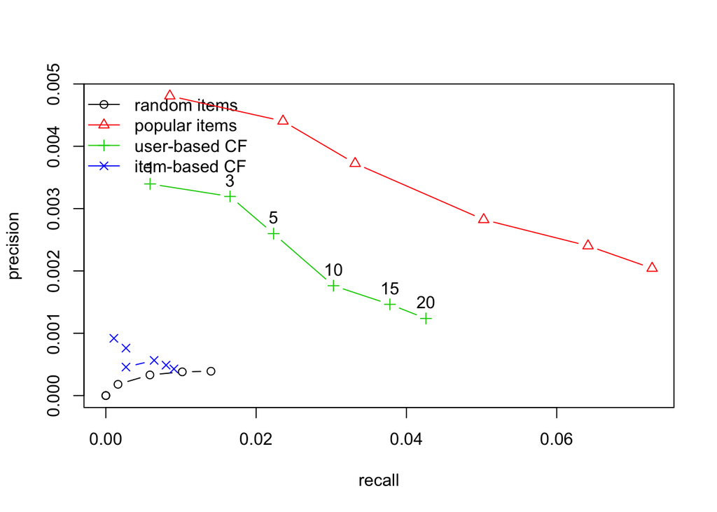

```r
plot(results_topN, "prec/rec", annotate=3, legend="topleft")
```

```r
## run algorithms
results_rating <- evaluate(scheme, algorithms, type = "ratings")
```

```
## RANDOM run fold/sample [model time/prediction time]
##   1  [0.001sec/1.255sec]
##   2  [0.001sec/1.253sec]
##   3  [0.001sec/1.67sec]
##   4  [0.001sec/1.271sec]
## POPULAR run fold/sample [model time/prediction time]
##   1  [0.006sec/0.732sec]
##   2  [0.005sec/0.765sec]
##   3  [0.007sec/0.783sec]
##   4  [0.005sec/0.724sec]
## UBCF run fold/sample [model time/prediction time]
##   1  [0.004sec/39.292sec]
##   2  [0.003sec/39.117sec]
##   3  [0.004sec/39.438sec]
##   4  [0.003sec/40.419sec]
## IBCF run fold/sample [model time/prediction time]
##   1  [41.873sec/0.376sec]
##   2  [41.888sec/0.37sec]
##   3  [41.608sec/0.38sec]
##   4  [41.851sec/0.325sec]
```

```r
results_rating
```

```
## List of evaluation results for 4 recommenders:
## Evaluation results for 4 folds/samples using method 'RANDOM'.
## Evaluation results for 4 folds/samples using method 'POPULAR'.
## Evaluation results for 4 folds/samples using method 'UBCF'.
## Evaluation results for 4 folds/samples using method 'IBCF'.
```

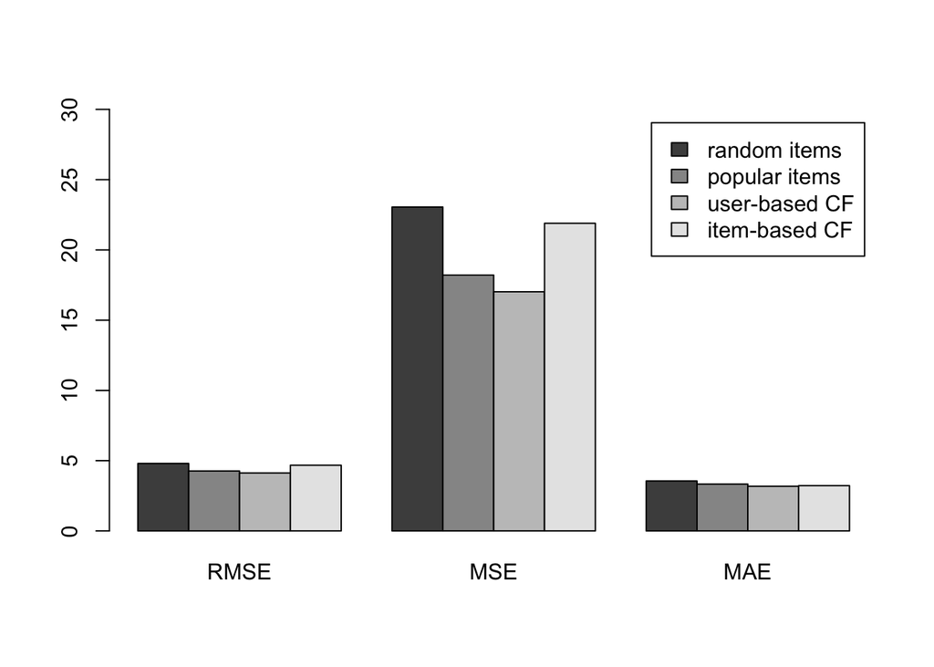

```r
plot(results_rating, ylim = c(0,30))
```

- Write down your observations based on the final performance table.

From the previous analysis, we can clearly see that there are no bigger differences in RMSE and MAE performance measurements in all four algorithms. But there is a difference in MSE measurement. The user-based CF algorithm performs the smallest value of MSE.